# Ross Datathon: Football Ticket Sales Analysis

## What is the question that your team set out to answer?

### Our team set out to answer "Which major groups should we target marketing efforts on?"

## We started by hypothesizing that alumni are more willing to buy football tickets than the general public.

## We had a hunch alumni might be more willing to buy football tickets than the general public:

#### According to the [NY Times](https://www.nytimes.com/interactive/projects/college-mobility/university-of-michigan-ann-arbor), in 2017, Michigan graduates had a median income of $68,700.

#### In contrast, according to [US Census ACS survey](https://www.deptofnumbers.com/income/michigan/), Michigan residents had a median income of $30,488.

## The main takeway from this comparison is that Michigan alumni have a lot more disposable income.

## In the next section, we investigate our hypothesis:

### Since we had sales data for the 2015-2019 football seasons, alumni data, and a unique ID for each buyer/alumni, we merge these two data sets by ID below:

```python
import pandas as pd
import numpy as np

f19_sales = pd.read_csv('../data/F19Sales.csv')
f18_sales = pd.read_csv('../data/F18Sales.csv')
f17_sales = pd.read_csv('../data/F17Sales.csv')
f16_sales = pd.read_csv('../data/F16Sales.csv')
f15_sales = pd.read_csv('../data/F15Sales.csv')

sales = pd.concat([f15_sales, f16_sales, f17_sales, f18_sales, f19_sales])
sales.rename(columns = {'Customer ID':'ID Value'}, inplace = True)

alum = pd.read_csv('../data/AlumniReport.csv')

merge = pd.merge(left=sales, right=alum, on=['ID Value'])

merge.head()
```

|  | ID Value | Item | Qty | PL | PT | I Disp | Seatblock | Priority Points | Item Cost | Csz | ... | Item Name | Degree | ID Type | Primary Degree Institution | Primary Degree Class Year | Primary Degree Education College | Primary Degree Education Status | Primary Address Country | Primary Address State | Primary Address Zip Code |
| --- | --- | --- | --- | --- | --- | --- | --- | --- | --- | --- | --- | --- | --- | --- | --- | --- | --- | --- | --- | --- | --- |
| 0 | 122853 | F02 | 2 | 1 | PD | M (Mail) | 1:23:40:26,25 | 999.13 | 200.0 | Frisco, TX 75034 | ... | Oregon State | B.S.E.(E.E.) 1966 College of Engineering | Athletics Ticket ID | University of Michigan - Ann Arbor | 1966.0 | College of Engineering | Graduated | United States | Texas | 75034 |
| 1 | 122853 | F03 | 2 | 1 | PD | S (Special Handling Required) | 1:23:40:4,3 | 999.13 | 230.0 | Frisco, TX 75034 | ... | Colorado | B.S.E.(E.E.) 1966 College of Engineering | Athletics Ticket ID | University of Michigan - Ann Arbor | 1966.0 | College of Engineering | Graduated | United States | Texas | 75034 |
| 2 | 122853 | F03 | 4 | 1 | PD | M (Mail) | 1:23:35:22,21 1:23:34:22,21 | 999.13 | 460.0 | Frisco, TX 75034 | ... | Colorado | B.S.E.(E.E.) 1966 College of Engineering | Athletics Ticket ID | University of Michigan - Ann Arbor | 1966.0 | College of Engineering | Graduated | United States | Texas | 75034 |
| 3 | 122853 | F05 | 2 | 1 | PD | M (Mail) | 1:22:21:2,1 | 999.13 | 310.0 | Frisco, TX 75034 | ... | Michigan State | B.S.E.(E.E.) 1966 College of Engineering | Athletics Ticket ID | University of Michigan - Ann Arbor | 1966.0 | College of Engineering | Graduated | United States | Texas | 75034 |
| 4 | 122853 | F12 | 2 | 1 | PD | M (Mail) | 1:22:21:2,1 | 999.13 | 310.0 | Frisco, TX 75034 | ... | Ohio State | B.S.E.(E.E.) 1966 College of Engineering | Athletics Ticket ID | University of Michigan - Ann Arbor | 1966.0 | College of Engineering | Graduated | United States | Texas | 75034 |

5 rows × 21 columns

## We want to investigate what percent of non-student tickets that alumni buy.

### First, we calculated the total number of football tickets sold.

```python
total_tickets_sold = 0
for qty in sales['Qty']:
    qty = qty.replace(',', '')
    total_tickets_sold += int(qty)

# Total number of tickets sold
print(total_tickets_sold)
```

```
905782
```

### We see that the total number of football tickets sold from 2015 to 2019 was 905,782 tickets.

### Next we calculate the total number of football tickets sold to alumni.

```python
# Find a alum grad. year for every ticket sold
sales_graduation_years = []
for i, year in enumerate(merge['Primary Degree Class Year']):
    for _ in range(int(merge['Qty'][i])):
        sales_graduation_years.append(int(year))

# Number of alum tickets sold
print(len(sales_graduation_years))
```

```
100955
```

### We see the that total number of football tickets sold to alumni from 2015 to 2019 was 100,955 tickets.

### Using the previous two cells, we calculate the proporation of tickets sold to alumni out of all tickets sold.

```python
# Prop of tickets sold to alum
prop_tix_sold_to_alum = (len(sales_graduation_years) / total_tickets_sold)
print(prop_tix_sold_to_alum * 100)
```

```
11.14561781974029
```

### We find that alumni buy about 11.15% of all non-student tickets sold.

## Next, we want to investigate the percent of non-student ticket revenue that alumni generate:

### First, we calculate the total dollar amount spent on football tickets from 2015-2019.

```python
# Find total money spent on tickets
total_money_spent = np.sum(sales['Item Cost'])
print(total_money_spent)
```

```
67823494.61999999
```

### We see the that total dollar amount spent on football tickets 2015 to 2019 was $67,823,494.61.

### Next, we calculate the total dollar amount alumni spent on football tickets from 2015-2019.

```python
# Find total money spent on tickets by alumni
total_money_spent_alum = np.sum(merge['Item Cost'])
print(total_money_spent_alum)
```

```
8518062.99
```

### We see the that total dollar amount alumni spent on football tickets 2015 to 2019 was $8,518,062.99.

### Using the previous two cells, we calculate the proporation of revenue generated by alumni out of total non-student ticket revenue.

```python
# Prop of revenue generated by alum
prop_rev_gen_by_alum = total_money_spent_alum / total_money_spent
print(prop_rev_gen_by_alum)
```

```
0.12559162629004625
```

### We find that alumni generate about 12.56% of all revenue generated by non-student tickets.

## Using the percent non-student tickets that were bought by alumni and the percent of non-student revenue that was generated by alumni, we can calculate how much more alumni spend on tickets versus the general public:

### Recall that alumni buy about 11.15% of all non-student tickets sold and generate about 12.56% of all revenue generated by non-student tickets.

### $\frac{12.56\%}{11.15\%} = 1.13$

```python
print(prop_rev_gen_by_alum / prop_tix_sold_to_alum)
```

```
1.126825164125112
```

## Takeaway: On average, alumni spend about 1.13x more on non-student football tickets than the general public.

## Overall, alumni are more willing to spend money on football tickets than the general public.

### Since we know alumni are more willing to spend money on football tickets AND have more disposable income, we will investigate alumni further.

## In this next section, we will see if there is a specific group within alumni that buy more tickets:

### Here we clean our data of any erroneous dates, and group alumni tickets sales by graduation year.

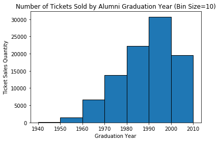

```python
import matplotlib.pyplot as plt

# Clean data, remove any years below 1900
while np.min(sales_graduation_years) < 1900:
    sales_graduation_years.remove(np.min(sales_graduation_years))

BIN_SIZE = 10

bins = np.arange(1940,2020,BIN_SIZE)

# Look at alum that bought tickets based on grad year
plt.hist(x=sales_graduation_years, bins=bins, edgecolor='black')
plt.title(f'Number of Tickets Sold by Alumni Graduation Year (Bin Size={BIN_SIZE})')
plt.ylabel('Ticket Sales Quantity')
plt.xlabel('Graduation Year')
```

### In this next section, we group alumni ticket sales by estimated age. We estimate age from graduation year.

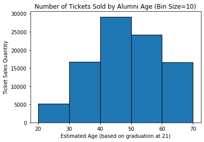

```python
# Estimate ages
AGE_OF_GRAD = 21

bins = np.arange(20, 80, BIN_SIZE)
ages = []
for year in sales_graduation_years:
    ages.append(2020 - (year - AGE_OF_GRAD))

plt.hist(x=ages, bins=bins, edgecolor='black')
plt.title(f'Number of Tickets Sold by Alumni Age (Bin Size={BIN_SIZE})')
plt.ylabel('Ticket Sales Quantity')
plt.xlabel('Estimated Age (based on graduation at 21)')
```

### We find that with a bin size of 10 years, 40-50 year old alumni bought the most non-student football tickets, followed closely by 50-60 year old alumni.

### In this next section, we group revenue generated by alumni ticket sales by graduation year.

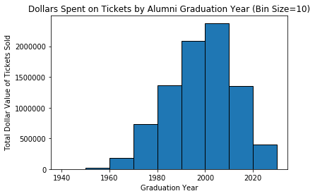

```python
years = list(rev_per_bin.keys())
values = list(rev_per_bin.values())

plt.bar(years, values, align='edge', width=BIN_SIZE, edgecolor='black')
plt.title(f'Dollars Spent on Tickets by Alumni Graduation Year (Bin Size={BIN_SIZE})')
plt.ylabel('Total Dollar Value of Tickets Sold')
plt.xlabel('Graduation Year')
```

### We find that with a bin size of 10 years, alumni that graduated from 2000-2010 generated the most non-student football ticket revenue, followed closely by alumni that graduated from 1990-2000.

### In this next section, we group revenue generated by alumni ticket sales by estimated age. We estimate age from graduation year.

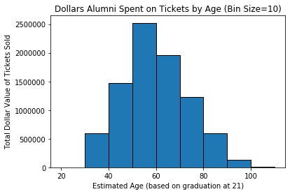

```python
ages = list(rev_per_bin_age.keys())
values = list(rev_per_bin_age.values())

plt.bar(ages, values, align='edge', width=BIN_SIZE, edgecolor='black')
plt.title(f'Dollars Alumni Spent on Tickets by Age (Bin Size={BIN_SIZE})')
plt.ylabel('Total Dollar Value of Tickets Sold')
plt.xlabel('Estimated Age (based on graduation at 21)')
```

### We find that with a bin size of 10 years, alumni that were 50-60 years old generated the most non-student football ticket revenue, followed closely by alumni that were 60-70 years old.

# Conclusion and Recommendations to Maximize Marketing Dollars

## If Michigan football wants to reach the majority of the 50-70 year old alumni demographic, they must use multi-channel methods to market tickets.

### This means many advertising efforts should be allocated to physical media such as magazines and postcards that this age demographic views.

## Lastly, Michigan football should run lots of Facebook ads targeting the 50-70 year old alumni demographic.

### Facebook provides the ability to only allocate advertising resources to extremely specific demographics, allowing for cost effective marketing.